# Creación de modelos para Glioblastoma

## Validación del modelo seleccionado

```r
test_pred <- predict(model.boost.PCA, newdata = gbm_dataset_v_PCA)
confusionMatrix.Boost.PCA <- confusionMatrix(table(test_pred, gbm_dataset_v_PCA$vital_status_at_12months_follow_up))
print(confusionMatrix.Boost.PCA)
```

```
Confusion Matrix and Statistics


test_pred  Deceased Living
  Deceased        3      2
  Living          1      3

               Accuracy : 0.6667
                 95% CI : (0.2993, 0.9251)
    No Information Rate : 0.5556
    P-Value [Acc > NIR] : 0.3743

                  Kappa : 0.3415

 Mcnemar's Test P-Value : 1.0000

            Sensitivity : 0.7500
            Specificity : 0.6000
         Pos Pred Value : 0.6000
         Neg Pred Value : 0.7500
             Prevalence : 0.4444
         Detection Rate : 0.3333
   Detection Prevalence : 0.5556
      Balanced Accuracy : 0.6750

       'Positive' Class : Deceased
```

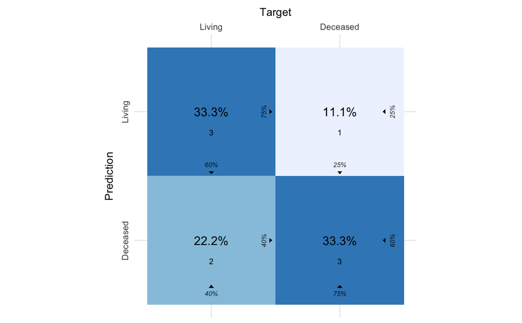

```r
plot_confusion_matrix(confusion_matrix(targets = gbm_dataset_v_PCA$vital_status_at_12months_follow_up, predictions = test_pred))
```

```r
test_pred <- predict(model.svm.PCA, newdata = gbm_dataset_v_PCA)
confusionMatrix.svm.PCA <- confusionMatrix(table(test_pred, gbm_dataset_v_PCA$vital_status_at_12months_follow_up))
print(confusionMatrix.svm.PCA)
```

```
Confusion Matrix and Statistics


test_pred  Deceased Living
  Deceased        0      1
  Living          4      4

               Accuracy : 0.4444
                 95% CI : (0.137, 0.788)
    No Information Rate : 0.5556
    P-Value [Acc > NIR] : 0.8426

                  Kappa : -0.2162

 Mcnemar's Test P-Value : 0.3711

            Sensitivity : 0.0000
            Specificity : 0.8000
         Pos Pred Value : 0.0000
         Neg Pred Value : 0.5000
             Prevalence : 0.4444
         Detection Rate : 0.0000
   Detection Prevalence : 0.1111
      Balanced Accuracy : 0.4000

       'Positive' Class : Deceased
```

[figure not shown]

```r
plot_confusion_matrix(confusion_matrix(targets = gbm_dataset_v_PCA$vital_status_at_12months_follow_up, predictions = test_pred))
```

```r
test_pred <- predict(model.svm, newdata = gbm_dataset_v)
confusionMatrix.svm <- confusionMatrix(table(test_pred, gbm_dataset_v$vital_status_at_12months_follow_up))
print(confusionMatrix.svm)
```

```
Confusion Matrix and Statistics


test_pred  Deceased Living
  Deceased        0      1
  Living          4      4

               Accuracy : 0.4444
                 95% CI : (0.137, 0.788)
    No Information Rate : 0.5556
    P-Value [Acc > NIR] : 0.8426

                  Kappa : -0.2162

 Mcnemar's Test P-Value : 0.3711

            Sensitivity : 0.0000
            Specificity : 0.8000
         Pos Pred Value : 0.0000
         Neg Pred Value : 0.5000
             Prevalence : 0.4444
         Detection Rate : 0.0000
   Detection Prevalence : 0.1111
      Balanced Accuracy : 0.4000

       'Positive' Class : Deceased
```

[figure not shown]

```r
plot_confusion_matrix(confusion_matrix(targets = gbm_dataset_v$vital_status_at_12months_follow_up, predictions = test_pred))
```

## Conclusiones

Observando los resultados obtenidos en la validación de los modelos, el algoritmo que mejor funciona se corresponde al Boosting con el dataset dónde a las variables se les aplica PCA, con un Accuracy de 0.67. Los otros modelos no son capaces de predecir correctamente a los pacientes que han muerto a los 12 meses del diagnóstico.

Con esto podemos concluir que o las características extraidas no son suficientemente representativas o que los pacientes disponibles no son suficientes para entrenar un modelo fiable para la predicción de la supervivencia de los pacientes a 12 meses del diagnóstico.